#### **To: My unreasonably demanding manager**

#### **From: Gareth Green**

Today’s business environment not only requires businesses to constantly review and adjust their advertising and promotion strategies; but also requires them to examine their competitors’ strategies. By finding the weakness in a competitor’s strategy, business can exploit opportunities to into that competitor’s space.

This memo will do both cited above, review and offer recommendations on our current strategies for advertisements and promotions and examine offer recommendation regarding our biggest competitor’s, Kelloggs, advertising and promotion strategy.

The next section reviews and makes recommendation countering Kellogg current advertising and promotion strategy.

### Recommendations:

1. We recommended that the advertising and promotion strategy work on a July-to-July calendar cycle.
2. We recommend small advertisements are the focus of effort throughout the year with an average of 2-3 advertisements per week.
3. We recommend minimal investment in medium advertisements during the July time frame then ramping up to 4-5 during the August to March time frame, then ramp back down to 1.2 for them remainder of the cycle.
4. We recommend that GM uses promotions in stores not running advertisements.

**Recommendation 1**: The graph below shows the advertisement trends for GM and Kelloggs over the year. We should expect that having more brands, Kellogg would have more advertisement per week. It is the overall advertising trends that are of most importance. The trends show that Kelloggs “front loads” its advertising at the beginning of the year with medium sized advertisements being the priority. This focus makes sense as the first half of the year has the NFL playoffs, NHL and NBA all-star games, and the start of the MLB season. All opportunities for their ads to reach the most consumers.

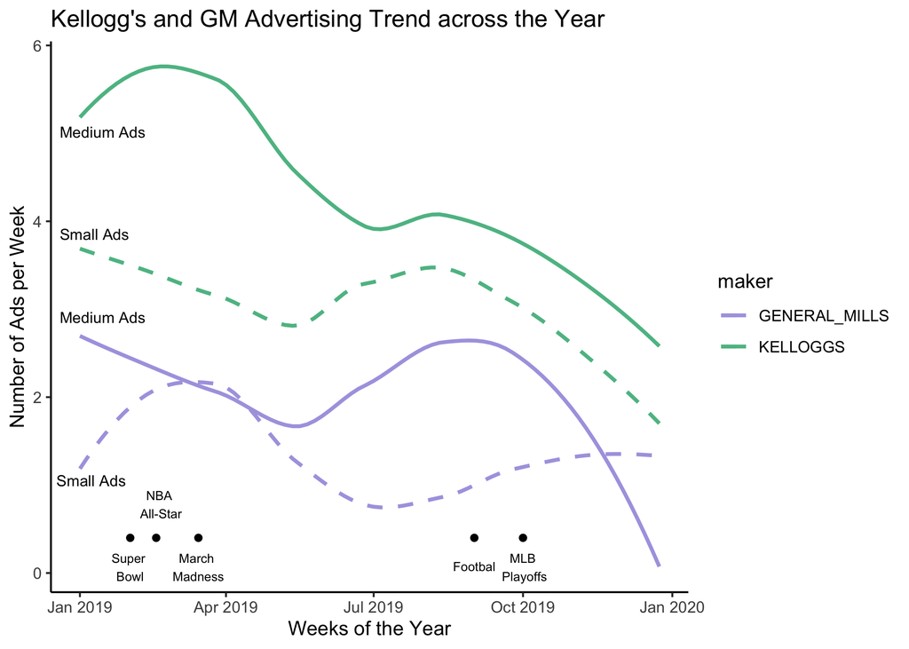

By realigning GM’s fiscal year to a July cycle allows GM to enter the second half of the year with a strong advertising budget/potential at a time when Kellogg’s is declining. This difference in advertising potential allows GM to be the predominantly seen brand the second half of the year, especially during football season, MLB playoffs and the start of the NBA and NHL seasons.

The graph below shows an example of the impact small advertisements have when compared to medium ads.

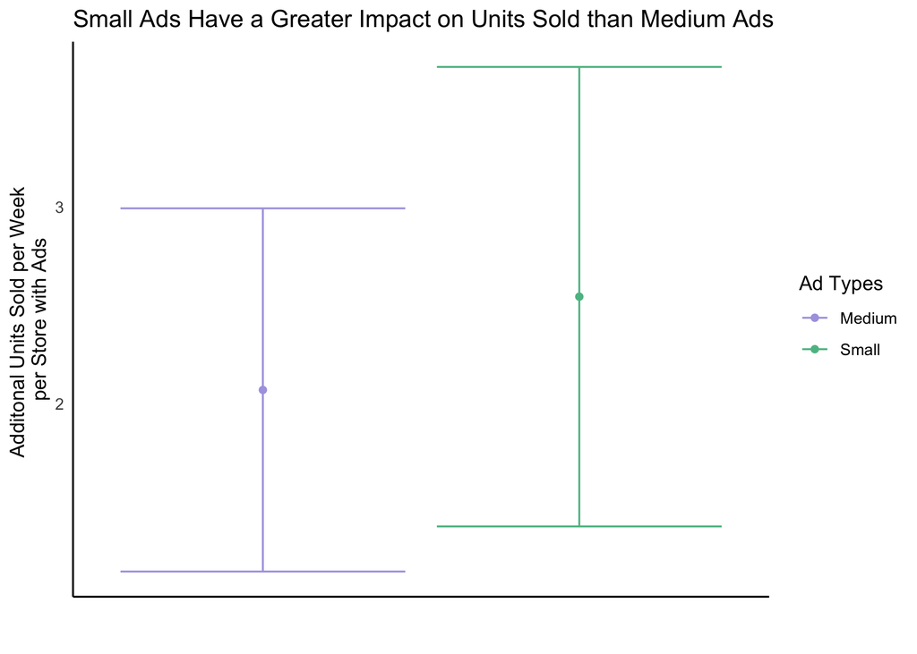

Best regards,

Gareth